# TADA Final Project: Lobbying Influence on Congressmembers’ Tweets about Guns and the Environment

Jean Pierre Salendres, Sarah Kennedy, and Michelangelo Freyrie

12/21/2020

# 1 Idea and Research Question

We set out to understand the impact of lobbying on Congressional communication on Twitter.

What can lobbying funds tell us about Congress members public rhetoric about key issues?

We will look specifically at two fields: the environment and gun control.

*Hypothesis*: We expect that Congresspeople who receive more funds from lobbyists on bills they have sponsored related to gun control or the environemnt will tweet more often about these respective issues. Moreover, controlling for party, higher lobbying levels will also lead to more negatively/positively charged speech on these issues.

We chose to work with data from the House of Representatives because they are typically more closely aligned with local interests and are more accountable to them (as they represent a smaller group of citizens) than Senators.

## 1.1 CODE

### 1.1.1 Twitter Data Merged with Congressmen Political Parties

```r
consolidated_congress_data <- read_delim("consolidated congress data.csv",
    ";", escape_double = FALSE, col_names = FALSE,
    trim_ws = TRUE)

data <- read_csv("tmls.csv")

data1 <- mutate(data, date = as.POSIXct(as.numeric(data$created_at), origin = '1970-01-01', tz = 'GMT')) %>% subset(select = -c(status_id, urls_url, reply_count, created_at, quote_count)) %>% subset(date > '2015-01-01')

party <- select(consolidated_congress_data,X1, X3, X10, X11)
colnames(party)  <- c("chamber","Party","Lobby_code","handle")

screen_name <- tolower(party$handle)
party <- cbind(party, screen_name)%>%
  na.omit()%>%
  select(-handle)

data1 <- merge(party, data1, by = "screen_name")
```

### 1.1.2 Corpus

```r
#Since we only have one relevant text column:
my_corp <- corpus(data1,
                  docid_field = 'X1', text_field = 'text')

#example of 100 characters of first text
txts <- texts(my_corp)
substr(txts[1], 1, 100)
```

```
##                                                                                                 936070
## "Please join me in sending cards to 9yo #JacobThompson who is fighting cancer at @MaineMed in #Portla"
```

```r
#how does our corpus look like
summary(my_corp, n = 10)
```

```
## Corpus consisting of 42354 documents, showing 10 documents:
##
##    Text Types Tokens Sentences    screen_name chamber    Party Lobby_code
##  936070    25     27         2 chelliepingree     rep Democrat    P000597
##  934975    44     54         2 chelliepingree     rep Democrat    P000597
##  936062    47     51         1 chelliepingree     rep Democrat    P000597
##  936069    22     22         1 chelliepingree     rep Democrat    P000597
##  934974    16     16         1 chelliepingree     rep Democrat    P000597
##  936051    34     40         2 chelliepingree     rep Democrat    P000597
##  936052    44     52         3 chelliepingree     rep Democrat    P000597
##  936068    33     42         1 chelliepingree     rep Democrat    P000597
##  934973    29     34         2 chelliepingree     rep Democrat    P000597
##  936055    29     35         1 chelliepingree     rep Democrat    P000597
##   user_id is_quote is_retweet favorite_count retweet_count
##  14984637    FALSE      FALSE             74            45
##  14984637    FALSE      FALSE             61            10
##  14984637    FALSE      FALSE            144            89
##  14984637    FALSE      FALSE              4             1
##  14984637    FALSE      FALSE            100            12
##  14984637    FALSE      FALSE              5             3
##  14984637    FALSE      FALSE             28            15
##  14984637    FALSE      FALSE              2             3
##  14984637    FALSE      FALSE             52            11
##  14984637    FALSE      FALSE              8             4
##                                   hashtags media_type         mentions_user_id
##             c("JacobThompson", "Portland")      photo                 36960073
##                                       <NA>       <NA>                     <NA>
##                   c("Maine", "mepolitics")       <NA>                     <NA>
##                              JacobThompson       <NA> c("36960073", "7744592")
##                                       <NA>       <NA>                     <NA>
##     c("Maine", "GOPtaxplan", "mepolitics")      photo                 38547254
##  c("Portland", "GOPTaxScam", "mepolitics")      photo                     <NA>
##                                       <NA>       <NA>                     <NA>
##                     c("HR8", "mepolitics")       <NA>                     <NA>
##              c("GOPTaxScam", "mepolitics")       <NA>                     <NA>
##        mentions_screen_name                date
##                    MaineMed 2017-11-07 19:49:55
##                        <NA> 2019-01-09 02:28:54
##                        <NA> 2017-11-09 18:32:43
##  c("MaineMed", "TODAYshow") 2017-11-07 20:00:35
##                        <NA> 2019-01-09 02:29:28
##               mainerealtors 2017-11-13 15:26:07
##                        <NA> 2017-11-13 15:16:11
##                        <NA> 2017-11-07 20:33:49
##                        <NA> 2019-01-09 15:12:08
##                        <NA> 2017-11-13 15:04:54
```

```r
#Key terms in play

tokens <- tokens(
  my_corp,
  what = "fasterword",
  remove_punct = TRUE,
  remove_symbols = TRUE,
  remove_numbers = FALSE,
  remove_url = TRUE,
  remove_separators = TRUE,
  split_hyphens = TRUE)
```

### 1.1.3 SPEECH

```r
#how is gun talked about
gun1 <- kwic(my_corp, "gun*", window = 10)
head(gun1, 10)
```

```
##
##  [934971, 37]
##  [936077, 16]
##  [936078, 17]
##  [936079, 14]
##  [934988, 20]
##  [935949, 27]
##  [935949, 56]
##   [935950, 3]
##  [935951, 33]
##  [934155, 43]
##
##                         to take action and pass#HR8, which will ensure |  guns
##                             bills to: Close terrorist watch list& amp; |  gun
##                          Sandy Hook, but not one piece of common sense |  gun
##                          for Texas. Senseless& amp; continuous acts of |  gun
##  inspired the nation with her resilience and advocacy for common-sense |  gun
##                              U+ 0097> especially to a senseless act of |  gun
##               your life. The Richardsons now advocate for common sense |  gun
##                                                      @RememberingD The |  gun
##                                        1: 30am in Jan. of 2010, masked | gunmen
##                       him in Selma, or sharing stories as we protested |  gun
##
##  | do not end up in the hands of those who
##  | show loopholes Pass#assaultweaponsban& amp;#backgroundchecks( 2
##  | legislation has passed Congress( 1/ 4)#mepolitics
##  | violence must be addressed. Congressional inaction is unacceptable!
##  | reform in the face of shootings in schools, houses
##  | violence. The" what-ifs" and the" whys
##  | laws w/@RememberingD. We must#HonorWithAction.(
##  | that killed Darien couldn't be traced+ her homicide investigation
##  | burst into her apartment and shot her several times in
##  | violence inaction, I've learned so much from his leadership
```

```r
#how is environment talked about
env1 <- kwic(my_corp, "environment*", window = 10)
head(env1, 10)
```

```
##
##  [936120, 12]              is bad for working families& amp; devastating for |
##  [936007, 36]  is deeply wrong and continues to go unchecked in professional |
##  [936021, 12] you know#Thanksgiving leftovers are delicious AND good for the |
##  [933584, 22]       everyone has a voice in federal projects that impact our |
##  [935881, 43]                                U+ 0092> s health, economy, and |
##  [934188, 22]                         which are a win-win for them& amp; our |
##  [934036, 13]                              wastes& gt; 30% of food, creating |
##  [934042, 41]     massive amounts of atmospheric carbon is a win-win for the |
##  [934103, 14] called#ForeverChemicals for their failure to break down in the |
##  [934106, 41]   nation dependent on fossil fuels. This decision imperils our |
##
##   environment  |
##  environments  |
##   environment  |
##   environment  |
##   environment  |
##   environment  |
##  environmental |
##   environment  |
##   environment  |
##   environment  |
##
##  < U+ 0097> will open drilling in Arctic
##  where victims are disempowered.#mepolitics
##  ? The@EPA estimates Americans threw out the equivalent of
##  . This thinly veiled sellout to corporate polluters undermines transparency
##  .#mepolitics https://t.co/zhBUlU01jq
##  ! As a member of@HouseAgDems& amp;@AppropsDems
##  problems& amp; economic losses. If we want
##  and the ag economy. https://t.co/H85sqNwfr8
##  or the human body. I was proud to join
##  and public health.#NoKXL https://t.co/UPx0P2TkqZ
```

### 1.1.4 Areas of interest: Guns and Environment

```r
#Applied to each of our areas of interest
# First Gun speech

guns <- kwic(my_corp, "gun*", window = 10)

guns_df <- tibble(screename = guns$docname,
                   text = paste(guns$pre, guns$post, sep = " "))
corp_guns <- corpus(guns_df)


#Second for environment speech

env <- kwic(my_corp, "environment*", window = 10)

env_df <- tibble(screename = env$docname,
                   text = paste(env$pre, env$post, sep = " "))
corp_env <- corpus(env_df)


#we can look at collocations by gun or env segment:
#guns_wording <- textstat_collocations(corp_guns, size = 2)
#env_wording <- textstat_collocations(corp_env, size = 4)

#on to a dfm
dfm <- dfm(my_corp, remove = stopwords("english"),
           stem = TRUE, remove_punct = TRUE, remove_numbers = TRUE, remove_symbols = TRUE, split_hyphens = TRUE)


#subset to get rid of retweets
dfm_new <- dfm_subset(dfm, is_retweet == FALSE)

#use of words by party
corpdfm_party <- dfm(dfm_new, groups = "Party")
small_corpdfm_party <- dfm_trim(corpdfm_party, min_docfreq = 2) #min 2 times word appears across all docs, cuts data

#frequencies
dfm_party <- dfm_group(corpdfm_party, "Party")

rep_terms <- textstat_keyness(dfm_party, "Republican")
head(rep_terms, 25)
```

```
##            feature      chi2 p n_target n_reference
## 1           alaska 1790.7648 0     1232           8
## 2             #ar3 1168.1629 0      792           0
## 3          alaskan  931.4259 0      634           1
## 4                u  868.2792 0     9861        9611
## 5          arkansa  506.5983 0      353           4
## 6               ak  463.7597 0      317           1
## 7           #gapol  409.5046 0      307          13
## 8           energi  379.8370 0      503         141
## 9            great  290.7914 0     1123         758
## 10 @sendansullivan  234.2907 0      159           0
## 11          arctic  223.9191 0      174          10
## 12           nativ  194.3532 0      273          83
## 13            fort  177.3575 0      150          14
## 14          @potus  173.3275 0      305         120
## 15           smith  171.4098 0      138          10
## 16          recent  165.0518 0      348         161
## 17           bless  154.8127 0      174          37
## 18           click  143.8987 0      153          29
## 19         congrat  137.2942 0      226          83
## 20            also  131.2922 0      446         282
## 21          pelosi  127.9122 0      108          10
## 22             god  126.0395 0      135          26
## 23          effort  124.0858 0      477         321
## 24         process  120.0864 0      325         180
## 25       constitut  115.0442 0      324         184
```

```r
dem_terms <-  textstat_keyness(dfm_party, "Democrat")
head(dem_terms, 25)
```

```
##       feature     chi2 p n_target n_reference
## 1    #mepolit 715.2562 0     1052           0
## 2       #ny19 465.4711 0      685           0
## 3      health 310.7473 0     1626         444
## 4        must 307.6383 0     1664         464
## 5  #teamtitus 290.7202 0      428           0
## 6      nevada 281.2532 0      418           1
## 7        main 268.1378 0      516          34
## 8       trump 254.9865 0     1712         539
## 9       fight 235.6416 0     1024         245
## 10        gun 216.9047 0      382          17
## 11        las 201.2524 0      308           3
## 12       vega 197.8572 0      303           3
## 13     hawaii 193.7832 0      297           3
## 14     worker 184.8982 0      845         210
## 15      #main 182.6746 0      269           0
## 16       town 177.9765 0      473          66
## 17     upstat 173.8430 0      256           0
## 18     farmer 173.8132 0      658         140
## 19       york 172.1995 0      269           4
## 20       food 171.5931 0      612         123
## 21     famili 169.9180 0     1894         736
## 22    million 161.9050 0      838         227
## 23       care 161.5788 0     1246         419
## 24      today 157.0772 0     2717        1200
## 25  administr 155.3582 0      764         200
```

```r
#stats on our groups
ntoken(dfm_party) # words on each side
```

```
##   Democrat Republican
##     389964     264711
```

### 1.1.5 Gun Dictionary

```r
#Dictionary creation

guns_dic1 <- dictionary(list(guns = phrase(c("gun violence", "gun*safety", "common*sense", "prevent gun*","commonsense*gun", "senseless*gun*", "gun*lobby", "gun*storage", "gunviolence*prevention", "unsecured*gun*", "gun*"))))

#check party dfm against new dictionary
dfm_party_dic <- dfm(dfm_new, dictionary = guns_dic1, group = "Party")


individ_guns <- dfm(dfm_new, dictionary = guns_dic1, group = "screen_name")
```

### 1.1.6 Environment Dictionary

```r
envi_dic <- dictionary(list(envi = phrase(c('climate*','environmental*protection', 'environmental*resources', 'the*arctic', 'natural*resources', 'interior', 'EPA', 'climate*', 'natural*disaster', 'natural*gas'))))

#check party dfm against new dictionary
dfm_envi_dic <- dfm(dfm_new, dictionary = envi_dic, group = "Party")


dfm_individ <- dfm(dfm_new, group = "screen_name", dictionary = envi_dic)
```

### 1.1.7 Full Dictionary

```r
full_dic <- dictionary(list(envi = c('climate','environmental protection', 'environmental resources', 'arctic', 'natural resources', 'interior', 'EPA', 'climate*', 'natural disaster', 'natural gas'), guns = c("gun violence", "gun safety",'sense', 'prevent','commonsense gun', 'senseless gun', 'gun lobby', 'gun storage', 'gunviolence prevention', 'unsecured gun', 'gun*')))

subdfm_full <- dfm(dfm_party) %>%
    dfm_select(pattern = full_dic, valuetype = "glob")

features_dfm_full <- textstat_frequency(subdfm_full, n = 40)

# Sort by reverse frequency order
features_dfm_full$feature <- with(features_dfm_full, reorder(feature, -frequency))

#plot
dictionary_plot <- ggplot(features_dfm_full, aes(x = feature, y = frequency)) +
    geom_point() +
    theme(axis.text.x = element_text(angle = 90, hjust = 1))+
  theme_bw()
```

```r
my_corp2 <- my_corp
docnames(my_corp2) <- apply(docvars(my_corp2, c("screen_name", "Party")), 1, paste, collapse = ", ")
summary(my_corp2, n = 10)
```

```
## Corpus consisting of 42354 documents, showing 10 documents:
##
##                         Text Types Tokens Sentences    screen_name chamber
##   chelliepingree, Democrat.1    25     27         2 chelliepingree     rep
##   chelliepingree, Democrat.2    44     54         2 chelliepingree     rep
##   chelliepingree, Democrat.3    47     51         1 chelliepingree     rep
##   chelliepingree, Democrat.4    22     22         1 chelliepingree     rep
##   chelliepingree, Democrat.5    16     16         1 chelliepingree     rep
##   chelliepingree, Democrat.6    34     40         2 chelliepingree     rep
##   chelliepingree, Democrat.7    44     52         3 chelliepingree     rep
##   chelliepingree, Democrat.8    33     42         1 chelliepingree     rep
##   chelliepingree, Democrat.9    29     34         2 chelliepingree     rep
##  chelliepingree, Democrat.10    29     35         1 chelliepingree     rep
##     Party Lobby_code  user_id is_quote is_retweet favorite_count retweet_count
##  Democrat    P000597 14984637    FALSE      FALSE             74            45
##  Democrat    P000597 14984637    FALSE      FALSE             61            10
##  Democrat    P000597 14984637    FALSE      FALSE            144            89
##  Democrat    P000597 14984637    FALSE      FALSE              4             1
##  Democrat    P000597 14984637    FALSE      FALSE            100            12
##  Democrat    P000597 14984637    FALSE      FALSE              5             3
##  Democrat    P000597 14984637    FALSE      FALSE             28            15
##  Democrat    P000597 14984637    FALSE      FALSE              2             3
##  Democrat    P000597 14984637    FALSE      FALSE             52            11
##  Democrat    P000597 14984637    FALSE      FALSE              8             4
##                                   hashtags media_type         mentions_user_id
##             c("JacobThompson", "Portland")      photo                 36960073
##                                       <NA>       <NA>                     <NA>
##                   c("Maine", "mepolitics")       <NA>                     <NA>
##                              JacobThompson       <NA> c("36960073", "7744592")
##                                       <NA>       <NA>                     <NA>
##     c("Maine", "GOPtaxplan", "mepolitics")      photo                 38547254
##  c("Portland", "GOPTaxScam", "mepolitics")      photo                     <NA>
##                                       <NA>       <NA>                     <NA>
##                     c("HR8", "mepolitics")       <NA>                     <NA>
##              c("GOPTaxScam", "mepolitics")       <NA>                     <NA>
##        mentions_screen_name                date
##                    MaineMed 2017-11-07 19:49:55
##                        <NA> 2019-01-09 02:28:54
##                        <NA> 2017-11-09 18:32:43
##  c("MaineMed", "TODAYshow") 2017-11-07 20:00:35
##                        <NA> 2019-01-09 02:29:28
##               mainerealtors 2017-11-13 15:26:07
##                        <NA> 2017-11-13 15:16:11
##                        <NA> 2017-11-07 20:33:49
##                        <NA> 2019-01-09 15:12:08
##                        <NA> 2017-11-13 15:04:54
```

```r
dispersion_plot <- kwic(my_corp2, pattern = "guns") %>%
    textplot_xray()
```

### 1.1.8 Wrangling Lobby Data

```r
#downsize sponsored bills
sponsored_bills <- read_delim("sponsored_bills.csv",";", escape_double = FALSE, trim_ws = TRUE)
new1 <- subset.data.frame(sponsored_bills, sponsored_bills$report_year > "2014")
new_sponsored_bills <- na.omit(new1, Var = c("congress_id_handles.Tweetcongress"))
#write.csv(new_sponsored_bills,"new_sponsored_bills", row.names = FALSE)

#downsize lobbying contributions file
dataset_report_level <- read_csv("dataset___report_level.csv")
money1 <- subset.data.frame(dataset_report_level, dataset_report_level$report_year > "2014")
money2 <- subset.data.frame(money1, money1$amount != "$0.00")
#write.csv(money2,"new_dataset_report_level", row.names = FALSE)

#merge amount with congressmen dataset
TADA_data <- merge(x = money2, y = new_sponsored_bills, by = "client_uuid", all = FALSE)
#write.csv(TADA_data,"TADA_data", row.names = FALSE)

#downsize issue code lobby data to relevant ones for and environment
dataset_issue_level <- read_csv("dataset___issue_level.csv")
issues_env1 <- subset.data.frame(dataset_issue_level, dataset_issue_level$issue_code == list("ENV", "TRA","FUE","ENG", "NAT", "CHM"))
issues_env <- subset.data.frame(issues_env1, issues_env1$gov_entity == '{"HOUSE OF REPRESENTATIVES",SENATE}')

#downsize issue code lobby data to relevant ones for and environment
issues_gun1 <- subset.data.frame(dataset_issue_level, dataset_issue_level$issue_code == "FIR")
issues_gun <- subset.data.frame(issues_gun1, issues_gun1$gov_entity == '{"HOUSE OF REPRESENTATIVES",SENATE}')

#DATA ENV : merge with issue codes, this will be the FINAL dataset on the lobby side we will need.
TADA_env_data <- merge(x = TADA_data, y = issues_env, by = "report_uuid", all = FALSE)
#write.csv(TADA_env_data,"TADA_env_2015-2020", row.names = FALSE)

#DATA GUN : merge with issue codes, this will be the FINAL dataset on the lobby side we will need.
TADA_gun_data <- merge(x = TADA_data, y = issues_gun, by = "report_uuid", all = FALSE)
#write.csv(TADA_gun_data,"TADA_gun_2015-2020", row.names = FALSE)
```

### 1.1.9 Calculations

```r
#add up total lobby for each congressmen dataset
TADA_gun_data$amount <- as.factor(as.character(TADA_gun_data$amount))
TADA_gun_data$amount <- as.numeric(as.factor(TADA_gun_data$amount))


TADA_env_data$amount <- as.factor(as.character(TADA_env_data$amount))
TADA_env_data$amount <- as.numeric(as.factor(TADA_env_data$amount))

#sum for each congressman lobby money for env
money_env_totals <- TADA_env_data %>%
  group_by(congress_id_handles.TweetCongress, issue_code) %>%
  transmute(Total=sum(amount))

money_env_peryear <- TADA_env_data %>%
  group_by(congress_id_handles.TweetCongress, issue_code, report_year.x) %>%
  transmute(Total=sum(amount))

#sum for each congressman lobby money for guns
money_gun_totals <- TADA_gun_data %>%
  group_by(congress_id_handles.TweetCongress, issue_code) %>%
  transmute(Total=sum(amount))

money_gun_peryear <- TADA_gun_data %>%
  group_by(congress_id_handles.TweetCongress, issue_code, report_year.x) %>%
  transmute(Total=sum(amount))

#unique senators with contributions to their name
df_money_env <- unique(money_env_totals)
#write.csv(df_money_env,"df_money_env", row.names = FALSE)

df_money_env_peryear <- unique(money_env_peryear)
#write.csv(df_money_env_peryear,"df_money_env_peryear", row.names = FALSE)

df_money_gun <- unique(money_gun_totals)
#write.csv(df_money_gun,"df_money_gun", row.names = FALSE)

df_money_gun_peryear <- unique(money_gun_peryear)
#write.csv(df_money_gun_peryear,"df_money_gun_peryear", row.names = FALSE)
```

### 1.1.10 Graphs

```r
#plotting the data
options(scipen=999)

env_lobby_graph <- ggplot(df_money_env_peryear) +
  aes(x = report_year.x, y = Total, color = issue_code, fill=issue_code) +
  geom_text(aes(label = congress_id_handles.TweetCongress), check_overlap = TRUE,
  size = 1.8,
  vjust = -1) +
  scale_x_continuous(name="Lobbying Years", limits=c(2015, 2020)) +
  scale_y_continuous(name="Environment Lobbying Amount", limits=c(30000, 100000)) +
  scale_color_discrete(name = "Lobby Areas", labels = c("Chemicals", "Energy","Environment","Fuels", "Natural Resources", "Transport"))



gun_lobby_graph <- ggplot(df_money_gun_peryear) +
  aes(x = report_year.x, y = Total) +
  geom_text(aes(label = congress_id_handles.TweetCongress), check_overlap = TRUE,
  size = 1.8,
  vjust = -1) +
  scale_x_continuous(name="Lobbying Years", limits=c(2015, 2020)) +
  scale_y_continuous(name="Gun Lobbying Amount", limits=c(0, 25000))
```

### 1.1.11 Twitter API extraction

```r
api_key1 <- "8iJelpReXMwWR5xUSY6TzrESY"
api_secret_key1 <- "LRZVxZ3ew0CyP6ixogTfvxr40nOIU0yUfMa1crieTlvvsOmkSD"

token1 <- create_token(
  app = "pesco-app",
  consumer_key = api_key1,
  consumer_secret = api_secret_key1)

handles_top <- head(handles2, n=176)

tmls <- get_timelines(
  handles_top$User, n = 25000)

write.table(tmls, file = "tmls_01-176.csv")
write.csv()
```

### 1.1.12 Plots

```r
#Create Frequency Plot
no_U <- dfm_remove(dfm_party, pattern = c("@*", "U", "#*", "amp", "today", "s*", "", "t", "w", "can", "fe0f"))
no_U2 <- dfm_remove(no_U, stopwords("en"))

features_dfm_tweets <- textstat_frequency(no_U2, n = 60)

# Sort by reverse frequency order
features_dfm_tweets$feature <- with(features_dfm_tweets, reorder(feature, -frequency))

twitter_plot2 <- ggplot(features_dfm_tweets, aes(x = feature, y = frequency)) +
    geom_point() +
    theme(axis.text.x = element_text(angle = 90, hjust = 1))
```

### 1.1.13 Causal Analysis

```r
library(stargazer)
#data frame matrix from applying gun dictionary and convert to data frame

individ_guns_final <- as.data.frame(
  individ_guns,
  row.names = NULL,
  document = docnames(individ_guns),
  docid_field = "congress_id_handles.TweetCongress",
  check.names = FALSE
)

#data frame matrix from applying env dictionary and comvert to data frame

individ_env_final <- as.data.frame(
  dfm_individ,
  row.names = NULL,
  document = docnames(dfm_individ),
  docid_field = "congress_id_handles.TweetCongress",
  check.names = FALSE
)

#merge both of these files to have gun and env counts

TWITTER_ANALYSIS <- merge(x = individ_guns_final, y = individ_env_final, by = "congress_id_handles.TweetCongress", all = FALSE)


#merge twitter counts with our lobby amount totals, based on common congressmen ID (twitter handle)

FINAL_GUN_ANALYSIS <- merge(x = TWITTER_ANALYSIS, y = df_money_gun_peryear, by = "congress_id_handles.TweetCongress", all = FALSE)

FINAL_ENV_ANALYSIS <- merge(x = TWITTER_ANALYSIS, y = df_money_env_peryear, by = "congress_id_handles.TweetCongress", all = FALSE)

#Calculating basic regression model to test correlation of our hypothesis
#GUN
reg_basic <- lm(guns ~ Total + report_year.x, FINAL_GUN_ANALYSIS)
stargazer(reg_basic, type ="html")
```

|  | *Dependent variable:* |
| --- | --- |
|  | guns |
| Total | -0.023*** |
|  | (0.007) |
| report_year.x | -4.189 |
|  | (2.693) |
| Constant | 8,519.616 |
|  | (5,434.939) |
| Observations | 11 |
| R<sup>2</sup> | 0.628 |
| Adjusted R<sup>2</sup> | 0.535 |
| Residual Std. Error | 13.890 (df = 8) |
| F Statistic | 6.750** (df = 2; 8) |
| *Note:* | p<0.1; p<0.05; p<0.01 |

```r
#ENVIRONMENT
reg_basic2 <- lm(envi ~ Total + issue_code + report_year.x, FINAL_ENV_ANALYSIS)
stargazer(reg_basic2, type ="html")
```

|  | *Dependent variable:* |
| --- | --- |
|  | envi |
| Total | -0.00002 |
|  | (0.001) |
| issue_codeENG | -4.947* |
|  | (2.871) |
| issue_codeENV | -5.493* |
|  | (3.203) |
| issue_codeFUE | -2.712 |
|  | (3.872) |
| issue_codeNAT | -7.863** |
|  | (3.069) |
| issue_codeTRA | -6.811** |
|  | (2.640) |
| report_year.x | 0.317 |
|  | (0.458) |
| Constant | -627.950 |
|  | (924.533) |
| Observations | 54 |
| R<sup>2</sup> | 0.183 |
| Adjusted R<sup>2</sup> | 0.058 |
| Residual Std. Error | 5.464 (df = 46) |
| F Statistic | 1.469 (df = 7; 46) |
| *Note:* | p<0.1; p<0.05; p<0.01 |

## 1.2 ANALYSIS

### 1.2.1 LOBBYING

The Lobby data is linked to bills sponsored in the House of Representatives and we link this money to Congressmen sponsors of the bill. This means that the monetary lobby contriution is not direct to the congress member but encompasses a lobby effort for the sponsored bill in question. This link is sufficient since our hypothesis points to these lobbying contributions as influencers of debate on the house floor (sponsored bills) and Congress member’s public rhetoric (Tweets).

### 1.2.2 LOBBYING VISUALIZATION

It is important to note thet in the environemntal-related lobbying chart below we have included various lobby areas that are linked in some way to the general idea of environment. We expect that most of these areas will have a negative speech effect, or abstinence of pro-environemnt speech, on Congressmen i.e. Chemicals, Fuels, Transport). Environment is the only variable that we expect to have a positive effect on speech pro-environment. Lastly, we expect Energy to be mixed and produce more conversation on the environment but on both negative and positive directions, due to the variance of energy groups across energy sources (some more environmentally-friendly than others).

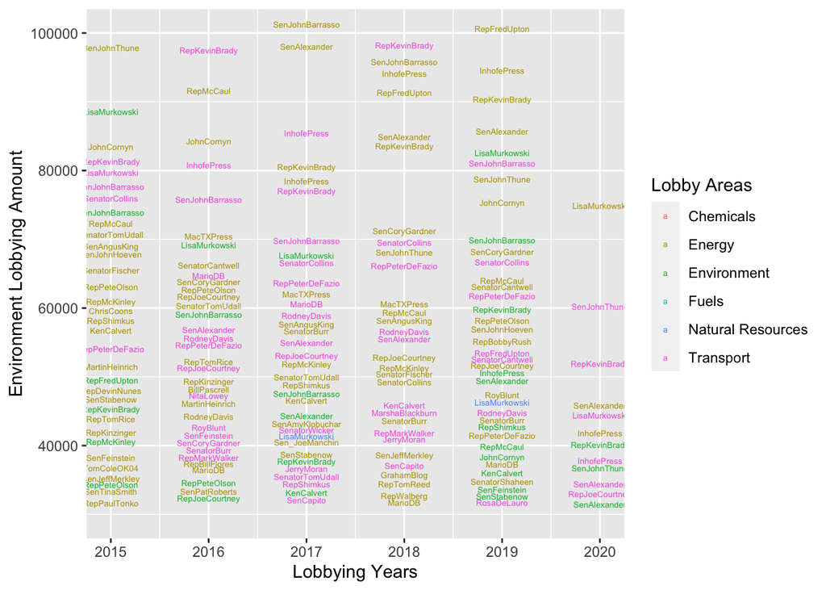

```r
env_lobby_graph
```

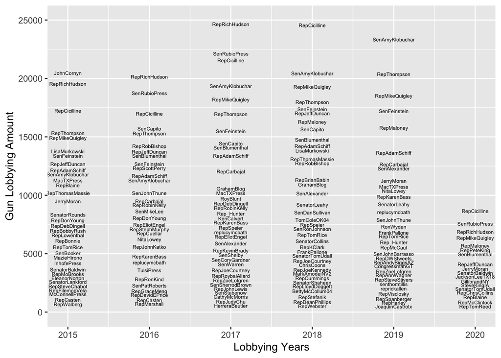

```r
gun_lobby_graph
```

### 1.2.3 TWEETS

We use this data as evidence of the political communication surrounding important issues for the Congress member and his audience, including on gun control and environmental legislation. We assume that there is an incentive for congress members to use Twitter communication to disseminated their views and political interests.

Below are a few visualizations of the twitter data we have for all Congress members:

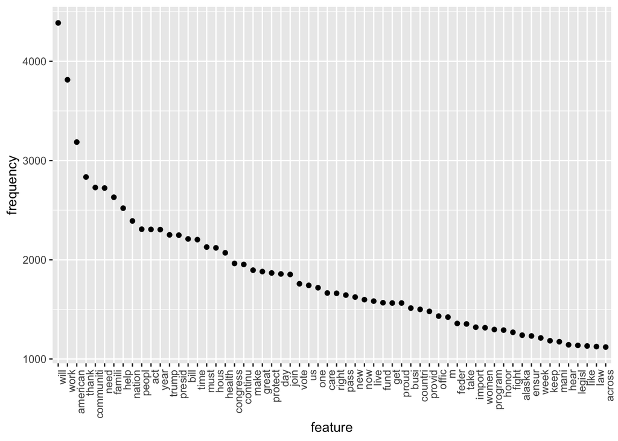

```r
twitter_plot2
```

Zooming in to conversation about guns, we see the lexical dispersion for the word “guns” and how it varies in use by congressmen.

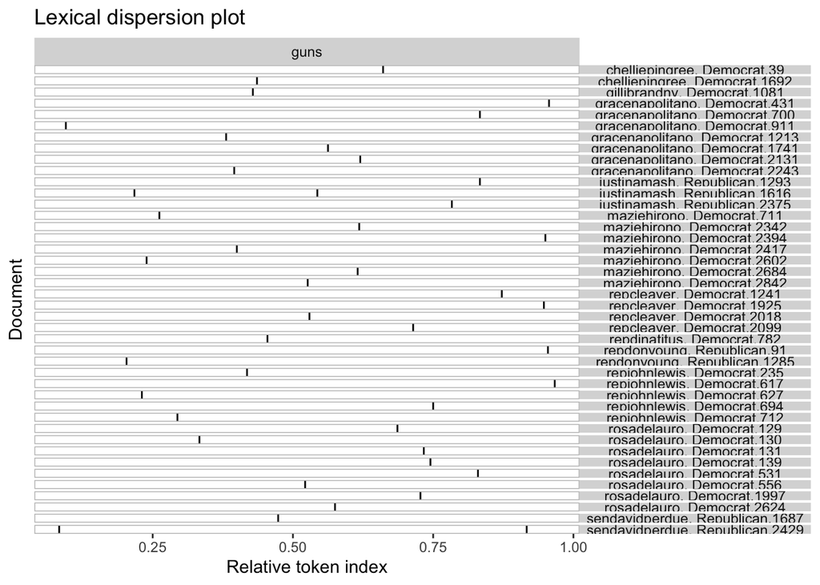

```r
dispersion_plot
```

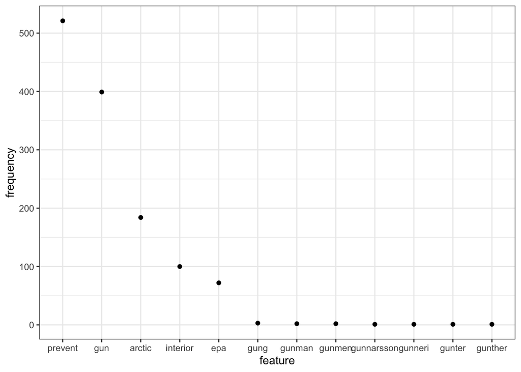

```r
dictionary_plot
```

### 1.2.4 ANALYSIS

As can be seen in the code sections, we created a dictionary for environment-debate terms and one for gun-debate related terms. These dictionaries helped us analyse the twitter data from all congressmen and create counts for hits of the dictionary on the individuals’ tweets.

As with all dictionary creation, more research and time should be devoted to perfect the dictionary (if that is ever possible) so we may get better coverage and precision.

These dictionaries allowed us to create the variation among congressmen that we needed in order to evaluate our hypothesis of whether lobby money affects the degree to which a congress member talks about these issues.

As indicated in the lobby code, the lobby data has been curated to create lobby contribution totals

### 1.2.5 THE MODEL

PART I: DEPENDENT VARIABLE (DV)

Congressmembers Twitter data analyzed through the prism of environmental and gun dictionaries will form the basis of our dependent variable (counts of related vocabulary use)

PART II: INDEPENDENT VARIABLES + CONTROLS

The lobby data that has been segmented by total lobby contributions for each congress members in 1) gun-related areas and 2)environmental related areas. The latter includes contributions by lobbies in areas of transport, fuels, natural resources, energy, that we expect to have negative coefficients and to reduce environmental speech of the congress member. We expect environment to be the only variable with a positive coefficient. Contributions are much lower in this area and therefore we are mainly looking at the “anti-environment” lobby areas described. The assumption we have is that these areas will push congress members to focus less on environment since the lobby areas rely on fossil fuels, natural resources, or other polluting susbtances.

We will run this totals as variation to see effect on IV. Some controls added are the year and lobby issue sub-code.

### 1.2.6 FINDINGS

Exploring text as data was useful and a great part of the project. The causal analysis part and the regression model gave us good intitial results.

Gun Model Results:

```r
stargazer(reg_basic, type ="html")
```

|  | *Dependent variable:* |
| --- | --- |
|  | guns |
| Total | -0.023*** |
|  | (0.007) |
| report_year.x | -4.189 |
|  | (2.693) |
| Constant | 8,519.616 |
|  | (5,434.939) |
| Observations | 11 |
| R<sup>2</sup> | 0.628 |
| Adjusted R<sup>2</sup> | 0.535 |
| Residual Std. Error | 13.890 (df = 8) |
| F Statistic | 6.750** (df = 2; 8) |
| *Note:* | p<0.1; p<0.05; p<0.01 |

We can see that for each dollar received from the gun lobby decreases congress members gun speech by -0.023 words, a statistically significant result with 99% confidence level. This is small yet considerable since it is attached to total dollar amount which goes up to 25,000 dollars in our dataset for gun lobbying contributions.

Therefore, someone who receives 25,000 USD will use 575 less gun related words or phrases from our dictionary. Notice that the constant and the year coefficient balance each other out (8,519 (constant) + year*(-4.189)) = 8,519 - (8440 to 8461) depending on year 2ß15-2020. Therefore from 59 to 79 dictionary words vary per year and the rest is an effect of lobby controbution coefficient.

The observations are too small and therefore we need to raise the quality of data to have more statistical power.

Environment Model Results:

```r
stargazer(reg_basic2, type ="html")
```

|  | *Dependent variable:* |
| --- | --- |
|  | envi |
| Total | -0.00002 |
|  | (0.001) |
| issue_codeENG | -4.947* |
|  | (2.871) |
| issue_codeENV | -5.493* |
|  | (3.203) |
| issue_codeFUE | -2.712 |
|  | (3.872) |
| issue_codeNAT | -7.863** |
|  | (3.069) |
| issue_codeTRA | -6.811** |
|  | (2.640) |
| report_year.x | 0.317 |
|  | (0.458) |
| Constant | -627.950 |
|  | (924.533) |
| Observations | 54 |
| R<sup>2</sup> | 0.183 |
| Adjusted R<sup>2</sup> | 0.058 |
| Residual Std. Error | 5.464 (df = 46) |
| F Statistic | 1.469 (df = 7; 46) |
| *Note:* | p<0.1; p<0.05; p<0.01 |

For the environemntal part, we see the coefficients for each lobby area. We expected negative coefficients for all exceot for Environment. In the results, we see that we have a few robust results, for example for transport and natural resources lobby, having a strong negatuve impact on pro-environmental langauge use in Tweets from Congressmembers.

Our observations are much higher here but our main coefficient however, is not statistically significant although it is in the right (negative) direction. The coeff is small but since donations go all the way to 1.2 million dollars for some congress members in total, that coefficient could be significant in terms of word usage in twets. However, it is not statistically significant so further analysis needs to be done.

Specifically, we mixed a few areas of lobbying and this could have counteracted the effects of areas that may be relevant.

However we encountered several problems that should be further looked into to make the analysis more robust:

I. In the course of our dictionary creation, the gun-related and environmental-related dictionaries decreased our congress member count significantly. This seems to be a code bug issue that we could not overcome too well, since for both lists the congress members were small (but complete) There is no reason to believe dozens of other members should not have come up, since they also had words related to gun or environment in their tweets.

2. When merging with the lobby data, we went flost some additional congress members, after dropping those that did not have contributions. These numbers should be brougth up if we fix the issue described in Part I.
3. The model would benefit from additional controls for age of congress member, geographic region, and others that can help us analyse speech use and control for variation due tot hese ommitted variables.